# 第3回 欠測値への対応や標準化など前処理の実行

## 前回からの接続

第2回は、自転車シェアの台数を1本の式で当て、データを訓練とテストに分けて、まだ見ていないデータで実力を測りました。ただ、自転車のデータは、欠測値もなく、どの列も数の、整えられたデータでした。

今日から題材が変わります。現場のデータには、極端な値が混ざり、値が欠測し、文字の列が並び、列ごとに目盛りがばらばらです。そのままでは式に入れられないデータを、式に入れられる形に整えます。この作業を前処理（preprocessing）と呼びます。

## 今日の分析目標

あなたは民泊の新しいホストです。自分のマンションの一室を貸切で出すとき、1泊いくらの値段を付ければいいかに答える。

東京のAirbnbに掲載された約3万2千件の部屋のデータを整えて、料金を当てる線形回帰（linear regression）の式を作り、あなたの部屋に値段を付けます。今日いちばん時間をかけるのは、欠測値の扱いです。欠測した理由を確かめ、補完の方法の良し悪しを、答えの分かる欠測で評価します。

もう1つのねらいは、前処理を関数（`def`）にまとめ、引数を変えて使いこなせるようになることです。問題を1つ見つけるたびに小さな関数を1つ書き、最後にそれを組み合わせて、訓練・テスト・あなたの部屋に同じ整え方を当てます。最後の「目標に答えられたか」で振り返りましょう。

### 場面

あなたは、民泊を始めたばかりの新しいホストです。東京の自分のマンションの一室を、貸切で出したいと考えています。定員や寝室の数は、もう決まっています。

決めたいのは、掲載するときの1泊の値段です。その値段がどれくらい外れうるかも、知っておきたいところです。

### 手元のデータ

Inside Airbnbが公開している、東京のAirbnbの掲載32,361件です（2026年6月30日時点）。1行が1つの部屋で、地区・部屋のタイプ・定員・寝室数・ベッド数などが並びます。答えの列は、その部屋の1泊の料金（円）です。

第2回のデータとは違い、1泊500万円を超える部屋が混ざり、寝室数やバスルーム数がところどころ欠測しています。バスルーム数を「1.5 baths」のような文字で書いた列もあります。

### 最後に出す答え

あなたの部屋に付ける1泊の値段（円）と、その値段が、まだ見ていない部屋で平均何円外れるかです。

## 学習ゴール

この回を終えると、次のことができるようになります。

- 極端な値や、目標と別の種類の行を外すかどうかを、分布を見て判断し、その理由を言葉で説明できる
- 何度も使う処理を`def`で関数にまとめ、引数（既定値つきを含む）と戻り値を読み書きできる
- 欠測（missing value）の量と欠測した理由を確かめ、別の列から戻す・補完せずに使わない・ほかの列から予測して補完（imputation）する、を選べる
- 平均値補完（mean imputation）がなぜよくないかを、答えの分かる欠測で評価して説明できる
- 標準化（standardization）と正規化で列の目盛りをそろえ、線形回帰の予測は変わらないこと、正規化が極端な値に弱いことを確かめられる
- 区分を表す文字の列に番号を振ると何が起きるかを説明し、ダミー変数にして訓練の列にそろえられる
- 右に尾の長い値を対数にして当て、`np.exp`で元に戻せる
- 補完の方法を訓練データだけで決め、関数にして、テストと新しい部屋に同じように当てられる

## 0. 準備

### 最初に実行する：道具を呼び出す

- 役割：このノートで使う道具（ライブラリ）を呼び出す
- 入力：なし
- 出力：なし（終わるとセルの左に ✓ が付く）

`import`は道具箱を持ってくる命令、`from`は道具箱から1つだけ取り出す書き方です。今日も、numpy（`np`）・pandas（`pd`）・matplotlib（`plt`）・scikit-learnの4つを使います。

```python
import numpy as np
import pandas as pd
import matplotlib.pyplot as plt
from sklearn.linear_model import LinearRegression
from sklearn.model_selection import train_test_split
```

### 図の日本語を表示できるようにする

- 役割：図の中の日本語が □ にならないようにし、図の大きさと字の大きさをそろえる
- 入力：なし
- 出力：「セットアップ完了」の表示

`try:`から先は、日本語表示の道具が動かなくなったときの保険で、中身は読まなくてかまいません。

```python
# 日本語が図の中で □ になるのを防ぐ
!pip install -q japanize-matplotlib
try:
    import japanize_matplotlib
# japanize が動かなくなったときの保険：同梱フォントを直接登録する
except Exception:
    from importlib.util import find_spec
    from matplotlib import font_manager as fm
    from pathlib import Path
    spec = find_spec('japanize_matplotlib')
    ttf = None
    if spec:
        ttf = next(Path(spec.origin).parent.rglob('*.ttf'), None)
    if ttf:
        fm.fontManager.addfont(str(ttf))
        name = fm.FontProperties(fname=str(ttf)).get_name()
        plt.rcParams['font.family'] = name

plt.rcParams['figure.figsize'] = (9, 5)
plt.rcParams['font.size'] = 13
plt.rcParams['axes.unicode_minus'] = False  # マイナス記号の化けを防ぐ
print('セットアップ完了')
```

```
セットアップ完了
```

### お手本：表を読み込んで、列名を日本語にする

- 役割：CSVファイルの表を読み込み、英語の列名を日本語に付け替えて、先頭5行を見る
- 入力：データの置き場所`DATA_DIR`と、ファイル名`airbnb_tokyo.csv`
- 出力：表`raw`（このあと全部の節で使う元の表）

`{'元の名前': '新しい名前', ...}`の辞書を`rename(columns=...)`に渡すと、その対応どおりに列名を付け替えます。値は変わりません。元の表は、あとで何度も使うので`raw`（生のデータ）という名前にしておきます。

```python
# データはこのリポジトリから読み込む
DATA_DIR = ('https://raw.githubusercontent.com/k0heiun0/'
            'applied_exercise_preview/main/shared/data')
raw = pd.read_csv(f'{DATA_DIR}/airbnb_tokyo.csv')
ja_names = {'neighbourhood': '地区', 'room_type': '部屋のタイプ',
            'property_type': '建物のタイプ', 'accommodates': '定員',
            'bedrooms': '寝室数', 'beds': 'ベッド数',
            'bathrooms': 'バスルーム数',
            'bathrooms_text': 'バスルームの表記',
            'minimum_nights': '最低宿泊数',
            'availability_365': '予約可能日数',
            'number_of_reviews': 'レビュー数',
            'review_scores_rating': 'レビューの点数',
            'reviews_per_month': '月あたりレビュー数',
            'host_is_superhost': 'スーパーホスト',
            'host_listings_count': 'ホストの掲載数', 'price': '料金'}
raw = raw.rename(columns=ja_names)
raw.head()
```

|  | 地区 | 部屋のタイプ | 建物のタイプ | 定員 | 寝室数 | ベッド数 | バスルーム数 | バスルームの表記 | 最低宿泊数 | 予約可能日数 | レビュー数 | レビューの点数 | 月あたりレビュー数 | スーパーホスト | ホストの掲載数 | 料金 |
| --- | --- | --- | --- | --- | --- | --- | --- | --- | --- | --- | --- | --- | --- | --- | --- | --- |
| 0 | Nishitokyo Shi | Entire home/apt | Entire home | 11 | 3.0 | 9.0 | 2.0 | 2 baths | 2.0 | 65 | 234 | 4.83 | 2.65 | t | 5 | 49000 |
| 1 | Kodaira Shi | Entire home/apt | Entire rental unit | 2 | 1.0 | 1.0 | 1.0 | 1 bath | 4.0 | 364 | 0 | NaN | NaN | f | 10 | 9648 |
| 2 | Sumida Ku | Private room | Room in hotel | 2 | 1.0 | 1.0 | 1.0 | 1 shared bath | 1.0 | 270 | 0 | NaN | NaN | t | 8 | 5500 |
| 3 | Shinjuku Ku | Entire home/apt | Entire rental unit | 2 | 1.0 | 1.0 | 1.0 | 1 bath | 1.0 | 340 | 0 | NaN | NaN | f | 33 | 19100 |
| 4 | Itabashi Ku | Shared room | Shared room in home | 1 | NaN | 4.0 | 1.0 | 1 shared bath | 1.0 | 358 | 6 | 4.33 | 1.36 | f | 9 | 4416 |

各列の中身は次のとおりです。`NaN`と表示されたマスは、値が欠測している（空欄の）マスです。

| 日本語の名前 | 元の名前 | 中身 |
| --- | --- | --- |
| `地区` | `neighbourhood` | 区や市の名前（例: `Ota Ku`は大田区） |
| `部屋のタイプ` | `room_type` | 貸切（`Entire home/apt`）・個室・相部屋など |
| `建物のタイプ` | `property_type` | マンションの一室・一軒家など |
| `定員` | `accommodates` | 泊まれる人数 |
| `寝室数`・`ベッド数`・`バスルーム数` | `bedrooms`・`beds`・`bathrooms` | 部屋の設備の数 |
| `バスルームの表記` | `bathrooms_text` | バスルーム数を文字で書いたもの（例: `1.5 baths`） |
| `最低宿泊数` | `minimum_nights` | 何泊から予約できるか |
| `予約可能日数` | `availability_365` | この先1年で予約を受け付ける日数 |
| `レビュー数`・`レビューの点数`・`月あたりレビュー数` | `number_of_reviews`ほか | 泊まった人の評価 |
| `スーパーホスト`・`ホストの掲載数` | `host_is_superhost`ほか | 貸し手（ホスト）の情報 |
| `料金` | `price` | 1泊の料金（円）。当てたい値 |

### 分析の地図：今日はここ

データ解析は「① データの理解と目標の設定 → ② 前処理（preprocessing）とデータ解析 → ③ 結果の解釈と目標との整合」の3つのフェーズを回ります。今日は ② の前処理が中心です。

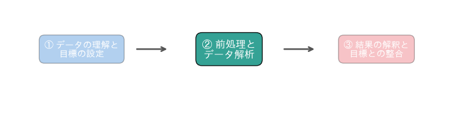

### 今日の道筋

前処理を進める順に、次の7つの小さな問いに答えていきます。

1. どの部屋を使う？（1〜2節）
2. なぜ欠測した？（3節）
3. どう補完する？（4〜5節）
4. 目盛りをそろえると？（6節）
5. 文字の列と、当てる値の形は？（7〜8節）
6. 同じ整え方を何度でも当てるには？（9節）
7. 1泊いくら？（10節）

## 1. どの部屋を相場に入れるか

表が読めました。値段は、ほかの部屋の料金を手がかりに付けます。まず、どんな部屋が並んでいるかを確かめ、相場に入れる部屋を決めます。

### お手本：料金の形を見る

- 役割：料金の要約とヒストグラムを出す
- 入力：表`raw`
- 出力：料金の要約と、ヒストグラム

`describe()`は、件数・平均・標準偏差（standard deviation）・最小・四分位・最大をまとめて出すメソッドです。`plt.hist`の`range=(0, 300000)`は、図に描く範囲を0〜30万円に決める引数です。

```
32361 件
count      32361.0
mean       31085.0
std        65610.0
min         1514.0
25%        13466.0
50%        19578.0
75%        30430.0
max      5449800.0
Name: 料金, dtype: float64
```

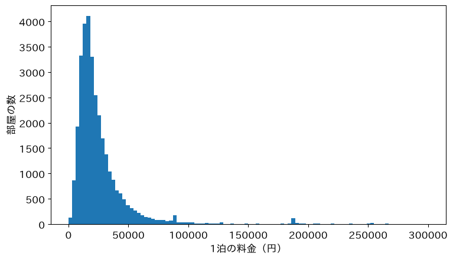

```python
print(len(raw), '件')
print(raw['料金'].describe().round(0))
plt.hist(raw['料金'], bins=100, range=(0, 300000))
plt.xlabel('1泊の料金（円）')
plt.ylabel('部屋の数')
plt.show()
```

料金の中央値（50%の行）は約2万円なのに、最大は545万円です。ヒストグラムは2万円あたりに山が1つあり、右に長い尾が伸びています（30万円より先にも、545万円まで続きます）。

1泊数十万〜数百万円の部屋としては、一棟貸しの大きな家や、特定の日だけ値段を上げた掲載などが考えられます。ふつうの部屋とは別の市場にあると考えたほうがよさそうです。「新しいホストが、ふつうの部屋に値段を付ける」という今日の目標の手がかりになりません。

外すときの約束は2つです。外す理由を目標から説明できること。そして、どこで線を引いたかを書き残すことです。今日は「1泊10万円以下」に絞ります。

### おさらい：条件で絞る

`raw[ ]`の中にTrue/Falseの並びを入れると、Trueの行だけが残ります。

```python
raw[raw['料金'] <= 100000]      # 10万円以下の部屋だけ
```

### 変えてみる：10万円以下の、貸切の部屋に絞る

- 役割：10万円以下の部屋を部屋のタイプごとに見てから、貸切の部屋に絞る
- 入力：表`raw`
- 出力：絞った表`df`と、その件数

`groupby('部屋のタイプ')`で部屋のタイプごとに分け、`agg(['median', 'count'])`で料金の中央値と件数を並べます。`reset_index(drop=True)`は、行の番号を0から振り直すメソッドです。

```python
df = raw[raw['料金'] <= 100000]                # 10万円以下の部屋だけ
print(len(raw) - len(df), '件を外した')
print(df.groupby('部屋のタイプ')['料金'].agg(['median', 'count']))
df = df[df['部屋のタイプ'] == 'Entire home/apt']  # 貸切の部屋だけ
print(df['最低宿泊数'].isna().sum(), '件は最低宿泊数が欠測している')
df = df[df['最低宿泊数'].notna()]   # その部屋を外す
df = df.reset_index(drop=True)                   # 行の番号を振り直す
print(len(df), '件')
```

```
902 件を外した
                  median  count
部屋のタイプ
Entire home/apt  20092.0  26433
Hotel room       10875.0    110
Private room     14580.0   4605
Shared room       3424.0    311
3 件は最低宿泊数が欠測している
26430 件
```

10万円を超えて外れたのは902件で、全体の2.8%です。貸切（`Entire home/apt`）の中央値は約2万円、相部屋（`Shared room`）は3千円台です。同じ「1泊の料金」でも、別の商品です。あなたが出したいのは貸切の部屋なので、貸切だけに絞ります。目標に照らして使う行を決めるのも、前処理です。

`最低宿泊数`が欠測した部屋は、貸切の中に3件だけありました（出力の2つ目の件数）。理由は分かりませんが、2万6千件のうちの3件なので外します。`notna()`は、欠測していないマスをTrueにするメソッドです（3節でくわしく扱います）。残ったのは26,430件です。

### お手本：先に、訓練とテストに分ける

- 役割：部屋を、訓練8割・テスト2割に分ける
- 入力：表`df`
- 出力：訓練の表`tr`とテストの表`te`

第2回と同じ`train_test_split`です。このあとの前処理は、すべて訓練データだけを見て決めます。テストは、まだ見ていない部屋の代わりとして、最後の評価にだけ使います。

```python
tr, te = train_test_split(df, test_size=0.2, random_state=42)
print(len(tr), len(te))
```

```
21144 5286
```

訓練は21,144件、テストは5,286件です。

## 2. 予測の誤差を測る関数

相場に入れる部屋が決まりました。今日は、整えるたびに「まだ見ていない部屋で何円外れるか」を何度も測ります。同じ計算を毎回書かずに済むよう、関数にします。

### お手本：MAEを関数にする

- 役割：実際の料金と予測から、MAE（円）を出す
- 入力：実際の料金`y`と、予測`pred`
- 出力：MAE（整数に丸めた円）

実際の料金$y_i$と予測$\hat{y}_i$の差の大きさ$\lvert y_i - \hat{y}_i \rvert$を絶対誤差と呼び、それを$n$件で平均したものを平均絶対誤差（MAE, mean absolute error）と呼びます。予測が平均で何円外れるかを表します。

$$\text{MAE} = \frac{1}{n}\sum_{i=1}^{n} \lvert y_i - \hat{y}_i \rvert$$

`def 名前(引数):`で関数を作ります。引数は関数が受け取るもの（入力）、`return`の後ろが関数が返すもの（戻り値、出力）です。これまで「役割・入力・出力」と読んできたかたまりに、名前を付けて何度も呼べるようにしたものが関数です。関数の中身は、字下げした行です。`np.abs`は絶対値、`.mean()`は平均、`round`は四捨五入です。

```python
def mae(y, pred):          # MAE
    return round(np.abs(y - pred).mean())
```

このセルを実行しても、何も表示されません。関数を作っただけだからです。使うには、名前にかっこを付けて引数を渡します（呼び出す）。

### 変えてみる：関数を呼び出す

- 役割：どの部屋も「訓練の料金の中央値」と答えたときの、テストでのMAEを測る
- 入力：訓練とテストの料金
- 出力：中央値と、MAE

何も工夫しない答えです。これを、このあと整えた式と比べる基準にします。

```python
base = np.median(tr['料金'])           # 訓練の中央値で答える
print(base)
print(mae(te['料金'], base), '円')     # 関数を呼び出す
```

```
20009.5
10860 円
```

どの部屋も約2万円と答えると、MAEは10,860円です。これが基準です。

### 式に入れようとすると、止まる

第2回のように、数の列を手がかりに線形回帰の式を作ろうとすると、次のエラーで止まります（このノートでは実行しません）。

```python
cols = ['定員', '寝室数', 'ベッド数', 'バスルーム数', '最低宿泊数',
        '予約可能日数', 'レビュー数', 'ホストの掲載数']
LinearRegression().fit(tr[cols], tr['料金'])
```

```
ValueError: Input X contains NaN.
```

いちばん下の行を読むと「手がかりの表`X`に`NaN`（欠測値）が入っている」とあります。欠測のマスがあると、式は作れません。欠測をどうにかするのが、次の仕事です。

```python
cols = ['定員', '寝室数', 'ベッド数', 'バスルーム数', '最低宿泊数',
        '予約可能日数', 'レビュー数', 'ホストの掲載数']
```

手がかりにする8本の列の名前を、`cols`にしまっておきます。

## 3. なぜ欠測したのか

欠測値があると、式が作れませんでした。すぐに補完したくなりますが、その前に、どの列がどれだけ、なぜ欠測したのかを確かめます。欠測した理由によって、扱い方が変わるからです。

### TODO①：列ごとの欠測の数と割合を表示する

`tr.isna()`は、各マスが欠測しているかをTrue/Falseで表します。`.sum()`で列ごとにTrueの数を、`.mean()`でTrueの割合を出せます（Trueは1、Falseは0として数えます）。欠測の割合は、欠測のマスの数を行の数$n$で割ったものです。訓練データ`tr`について、欠測の数と割合（%）を表示してください。

```python
# TODO: 訓練データ tr の、列ごとの欠測の数と割合（%）を表示する
# ヒント: tr.isna().sum() と tr.isna().mean() * 100
...;
```

欠測しているのは5つの列です。バスルーム数1,322件（6.3%）、寝室数1,025件（4.8%）、ベッド数838件（4.0%）、そしてレビューの点数と月あたりレビュー数が2,310件（10.9%）ずつです。地区や料金などの列は欠測していません。

欠測のしやすさが何で決まるかで、欠測は3つに分けられます。これを欠測のメカニズムと呼びます。

- 完全にランダムな欠測（MCAR, missing completely at random）：どの部屋も同じ確率で欠測する。入力し忘れなど
- ランダムな欠測（MAR, missing at random）：欠測のしやすさが、ほかの列で決まる。小さい部屋ほど欠測しやすい、など。ほかの列が同じ部屋どうしでは、欠測するかどうかはランダム、という意味でこう呼ぶ
- ランダムでない欠測（MNAR, missing not at random）：欠測のしやすさが、その値自身で決まる。値があり得ない、値が都合の悪いもの、など

どれにあたるかで、扱い方が変わります。順に見ていきます。

### お手本：レビューの点数は、なぜ欠測した？

- 役割：レビューが0件の部屋の数と、レビューの点数が欠測した部屋の数を比べる
- 入力：訓練の表`tr`
- 出力：3つの件数

`&`は「かつ」です。2つの条件の両方がTrueの行を数えます。

```python
no_review = tr['レビュー数'] == 0              # レビューが0件の部屋
no_score = tr['レビューの点数'].isna()        # 点数が欠測した部屋
print(no_review.sum(), no_score.sum())
print((no_review & no_score).sum())          # 両方にあてはまる部屋
```

```
2310 2310
2310
```

3つとも2,310件です。点数が欠測した部屋は、ぴったりレビューが0件の部屋でした。まだ誰も泊まっていないので、点数が付きようがないのです。値そのものが存在しない欠測です。

こうした欠測を平均点で補完すると、「まだ誰も泊まっていない」という情報が消え、泊まった人のいない部屋に、ありもしない点数が付きます。今日は、点数の列も月あたりレビュー数の列も使いません（レビューが0件かどうかは、`レビュー数`の列が持っています）。

### お手本：欠測したバスルーム数を見る

- 役割：バスルーム数が欠測した部屋を取り出し、文字の列`バスルームの表記`に何と書いてあるかを数える
- 入力：訓練の表`tr`
- 出力：欠測の件数と、表記の中身の多い順

`value_counts()`は、中身ごとの件数を多い順に並べるメソッドです。

```python
miss = tr['バスルーム数'].isna()      # 欠測した部屋は True
print(miss.sum(), '件')
print(tr[miss]['バスルームの表記'].value_counts())
```

```
1322 件
バスルームの表記
1 bath       1072
1.5 baths      95
2 baths        77
0 baths        39
Half-bath      15
3 baths         9
2.5 baths       9
3.5 baths       3
4 baths         2
4.5 baths       1
Name: count, dtype: int64
```

表記ごとの件数を足すと1,322件で、欠測の件数と同じです。欠測した部屋のどれにも、`1 bath`・`1.5 baths`・`Half-bath`のように表記が書いてあります。数の列だけが空欄になっていたのです。それなら、予測するより、文字から真の値を戻すほうが確かです。

### 変えてみる：文字1つを数1つに直す関数

- 役割：`'1.5 baths'`のような表記を1つ受け取り、バスルームの数を返す
- 入力：表記の文字`text`
- 出力：数（`1.5 baths`なら1.5）

`'1.5 baths'.split(' ')`は、空白で切り分けて`['1.5', 'baths']`にします。`[0]`で最初の`'1.5'`を取り、`float( )`で小数の数1.5にします。`'Half-bath'`（シャワーのない洗面所など、半分のバスルーム）だけは数が書いていないので、`if`で0.5を返します。`return`したところで関数は終わるので、`Half-bath`のときは下の行まで進みません。

```python
def bath_num(text):            # '1.5 baths' → 1.5
    if text == 'Half-bath':
        return 0.5
    return float(text.split(' ')[0])

print(bath_num('1.5 baths'), bath_num('Half-bath'))  # 確かめる
```

```
1.5 0.5
```

作った関数は、まず1回呼んで確かめます。`1.5`と`0.5`が出れば正しく動いています。

### 変えてみる：表の欠測を、文字から戻す関数

- 役割：表`d`の、欠測したバスルーム数を、表記から読み取った数で補完する
- 入力：表`d`（訓練でもテストでも新しい部屋でもよい）
- 出力：バスルーム数の欠測を補完した表

いま作った`bath_num`を、表の列全体に当てます。

欠測を補完する処理は、どのやり方でも次の1本の式で書けます。$x_i$は$i$番目の部屋の値、$\hat{x}_i$は欠測したときに入れる値（補完値）、$\tilde{x}_i$は補完したあとの値です。

$$\tilde{x}_i = \begin{cases} x_i & (\text{値がある}) \\ \hat{x}_i & (\text{欠測している}) \end{cases}$$

ここでの$\hat{x}_i$は、表記から読んだ数です。コードの`fillna(from_text)`が、この式そのものです。値があればそのまま、欠測していれば`from_text`の値にします。

- `d.copy()`：受け取った表の写しを作る。関数の外の表を、知らないうちに書き換えないため
- `map(bath_num)`：列の中身を1つずつ`bath_num`に通した列を返す
- `fillna(列)`：欠測のマスだけを、同じ行の値で補完する。欠測していないマスはそのまま

```python
def fill_bath(d):              # 欠測したバスルーム数を、文字から戻す
    d = d.copy()
    from_text = d['バスルームの表記'].map(bath_num)
    d['バスルーム数'] = d['バスルーム数'].fillna(from_text)
    return d

tr = fill_bath(tr)
te = fill_bath(te)
print(tr['バスルーム数'].isna().sum())
print(te['バスルーム数'].isna().sum())
```

```
0
0
```

戻したあとの欠測は、訓練もテストも0件です。その部屋の表記だけを読む処理なので、訓練・テストのどちらに当ててもかまいません。

`fill_bath`の形を覚えておいてください。「補完値の列を作り（`from_text`）、`fillna`で欠測のマスだけ差し替える」。このあと、回帰補完するときも同じ形を使います。

### 変えてみる：寝室数とベッド数は、どんな部屋で欠測した？

- 役割：寝室数が欠測した部屋と欠測していない部屋で、定員と料金の中央値を比べる。ベッド数でも定員を比べる
- 入力：訓練の表`tr`
- 出力：2つの表と、寝室数が0の部屋の数

`groupby`に、True/Falseの並びを渡すと、欠測した部屋（True）と欠測していない部屋（False）に分けて集計できます。

```python
miss_bed = tr['寝室数'].isna()           # 寝室数が欠測した部屋は True
print(tr.groupby(miss_bed)[['定員', '料金']].median())
print('寝室数が0の部屋:', (tr['寝室数'] == 0).sum(), '件')
miss_beds = tr['ベッド数'].isna()        # 欠測した部屋は True
print(tr.groupby(miss_beds)['定員'].median())
```

```
        定員       料金
寝室数
False  4.0  20358.0
True   2.0  15948.0
寝室数が0の部屋: 0 件
ベッド数
False    4.0
True     3.0
Name: 定員, dtype: float64
```

寝室数が欠測した部屋（True）は、定員の中央値が2人、料金が15,948円です。欠測していない部屋（False）は4人・20,358円です。欠測した部屋は、小さくて安い部屋に偏っています。ベッド数でも、欠測した部屋（True）の定員の中央値は3人で、欠測していない部屋の4人より小さくなります。ランダムな欠測（MAR）です。欠測のしやすさが、ほかの列（定員）で決まっています。

### 問い：寝室数0の部屋が、1件もない

寝室数が0の部屋は、1件もありません。寝室数が欠測した部屋は、定員2人の小さい部屋に偏っていました。この欠測は何を意味していそうでしょうか。予想を下に書いてください。

（ここに予想を書く）

ワンルーム（寝室として区切られた部屋がない）を、「0」ではなく欠測として登録した部屋が混ざっているのかもしれません。もしそうなら、ランダムでない欠測（MNAR）も混ざっています。値（0）そのものが、欠測の理由だからです。

どちらにしても、寝室数とベッド数は、料金の手がかりとして使いたい列です。欠測のまま外すと、小さい部屋ばかりが減ってしまいます。次の節で、どう補完するのがよいかを確かめます。

## 4. 補完の方法を評価する

寝室数とベッド数の欠測は、補完して使いたい列でした。ただ、真の値が分からない欠測では、補完した値が当たったかどうかを確かめられません。そこで、答えの分かる欠測を自分で作り、補完の方法を評価します。

ここで使うのは、練習用に作ったデータです。ベッド数が分かっている部屋から、わざと値を欠測させます。実際のデータの欠測は4%ほどですが、違いが見えやすいように、欠測率を上げて欠測させます。

### お手本：答えの分かる欠測を作る関数

- 役割：表`d`の列`col`の値を、定員の小さい部屋ほど多く欠測させる
- 入力：表`d`、欠測させる列`col`、欠測率の目安`rate`、乱数（random number）の種`seed`
- 出力：値を欠測させた表

これは練習用の道具です。役割・入力・出力と、次の1点だけ押さえれば、中身は読み飛ばしてかまいません。

`seed=0`のように、引数に`=`で値を書いておくと、呼び出すときに省いた場合はその値が使われます（既定値）。下の`make_missing(full, 'ベッド数', 0.2)`は、`seed`を書いていないので`seed=0`で動きます。

中身が気になる人へ：部屋$i$を欠測させる確率を$p_i$、欠測率の目安を$r$（`rate`）とすると、

$$p_i = \frac{4r}{\text{定員}_i}$$

です。`rng.random(len(d))`で0〜1の乱数を部屋の数だけ出し、それが$p_i$（`rate * 4 / d['定員']`）より小さい部屋を欠測させます。欠測させる確率は、定員4人の部屋で`rate`、2人でその2倍、8人で半分です。`d.loc[hide, col] = np.nan`は、`hide`がTrueの行の列`col`のマスを、欠測値`np.nan`で書き換えます。

```python
def make_missing(d, col, rate, seed=0):
    d = d.copy()
    rng = np.random.default_rng(seed)
    hide = rng.random(len(d)) < rate * 4 / d['定員']
    d.loc[hide, col] = np.nan
    return d

full = tr[tr['ベッド数'].notna()]    # ベッド数の分かる部屋
practice = make_missing(full, 'ベッド数', 0.2)
miss = practice['ベッド数'].isna()
print(len(full), '件のうち', miss.sum(), '件を欠測させた')
print(round(miss.mean() * 100, 1), '%')
```

```
20306 件のうち 4631 件を欠測させた
22.8 %
```

ベッド数が分かっている20,306件のうち、4,631件（22.8%）を欠測させました。欠測させた部屋の真のベッド数は、`full`に残っています。

### お手本：平均値補完して、評価する

- 役割：欠測させたベッド数を、残った部屋のベッド数の平均で補完し、真の値と比べる
- 入力：練習用の表`practice`と、真の値の表`full`
- 出力：補完値と、欠測させた部屋でのMAE

平均値補完するのは、補完の式の$\hat{x}_i$に、値の残った部屋（$O$）の平均を入れることです。部屋によらず、同じ値になります。

$$\hat{x}_i = \bar{x} = \frac{1}{|O|}\sum_{k \in O} x_k$$

評価は、欠測させた部屋（$M$）だけで、補完後の値$\tilde{x}_i$と真の値$x_i$の差の大きさを平均します。2節のMAEと同じ形です。

$$\frac{1}{|M|}\sum_{i \in M} \lvert \tilde{x}_i - x_i \rvert$$

`fillna(値)`は、欠測のマスを1つの値で置き換えます。`[miss]`で、欠測させた部屋だけを取り出してMAEを測ります。

```python
avg = practice['ベッド数'].mean()               # 残った部屋の平均
by_mean = practice['ベッド数'].fillna(avg)      # 欠測を平均値補完する
truth = full['ベッド数']                        # 真の値
print('補完値:', round(avg, 2))
print('MAE:', round(np.abs(by_mean - truth)[miss].mean(), 2), '台')
```

```
補完値: 3.27
MAE: 1.63 台
```

平均3.27台で補完すると、欠測させた部屋でのMAEは1.63台です。定員2人の部屋にも8人の部屋にも、同じ3.27台が入るからです。

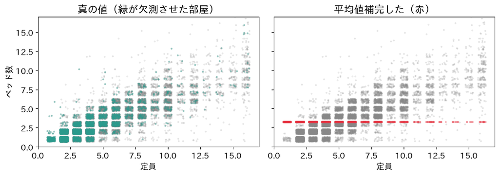

左が真の値、右が平均値補完の値です（点が重ならないよう、少しずらして描いています）。真の値では、定員が多いほどベッド数も多い右上がりの関係があります。平均値補完すると、欠測させた部屋（赤）は定員に関係なく3.27台の高さに一直線に並びます。

その結果、定員とベッド数の相関係数（2つの列の直線的な関係の強さ。−1〜1）も弱まります。

```python
print('真の値  :', round(full['定員'].corr(truth), 3))
print('平均値補完した:', round(full['定員'].corr(by_mean), 3))
```

```
真の値  : 0.848
平均値補完した: 0.762
```

真の相関は0.848。その関係が、平均値補完すると0.762まで弱まります。補完値が、定員の情報を無視しているからです。

### お手本：定員から回帰補完する

- 役割：値の分かる部屋で「定員からベッド数を当てる式」を作り、欠測した部屋をその予測値で補完する
- 入力：練習用の表`practice`
- 出力：回帰補完したベッド数`by_reg`

ベッド数は、定員と強く関係していました。それなら、第2回の線形回帰を、料金ではなくベッド数を当てるのに使えばよいはずです。この補完のしかたを、回帰補完（regression imputation）と呼びます。

$$\widehat{\text{ベッド数}} = a \times \text{定員} + b$$

$a$と$b$は、ベッド数の分かる部屋で決めます。やり方は、3節の`fill_bath`と同じ形です。補完値の列（ここでは`予測値`）を作り、`fillna`で欠測のマスだけ差し替えます。`practice['予測値'] = ...`のように、表に新しい列名で値を入れると、列が1本増えます。

```python
ok = practice[practice['ベッド数'].notna()]          # 値の分かる部屋
m_bed = LinearRegression().fit(ok[['定員']], ok['ベッド数'])
practice['予測値'] = m_bed.predict(practice[['定員']])
by_reg = practice['ベッド数'].fillna(practice['予測値'])
print('MAE:', round(np.abs(by_reg - truth)[miss].mean(), 2), '台')
print('相関:', round(full['定員'].corr(by_reg), 3))
```

```
MAE: 0.58 台
相関: 0.863
```

回帰補完すると、MAEは0.58台です。平均値補完した1.63台の、3分の1ほどに縮みました。相関も0.863と、真の0.848に近くなります（少し強めに出る理由は、発展で扱います）。

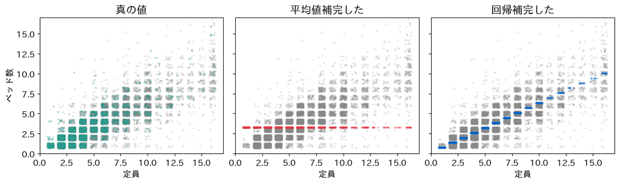

予測値（右、青）は、定員が増えるほど上がる1本の線に乗ります。平均値補完の値（中央、赤）のように、定員を無視することはありません。

### 変えてみる：評価を関数にまとめる

- 役割：欠測率`rate`で欠測を作り、平均値補完の場合と回帰補完した場合を評価して表示する
- 入力：欠測率の目安`rate`
- 出力：なし（欠測率・補完に使った平均・2つのMAEと相関を表示する）

欠測率を変えて、何度も評価し直したくなりました。上の3つのお手本のセルを、そのまま字下げして`def`の下に並べ、`rate`だけを引数にします。こうすると、`grade(0.4)`と1行書くだけで、欠測率0.4でやり直せます。

関数の中で作った名前（`practice`や`miss`など）は、その関数の中だけのものです。関数の外の`practice`や`miss`は書き換わりません。

```python
def grade(rate):           # 欠測率 rate で2つの補完を評価
    practice = make_missing(full, 'ベッド数', rate)
    miss = practice['ベッド数'].isna()
    avg = practice['ベッド数'].mean()
    by_mean = practice['ベッド数'].fillna(avg)
    ok = practice[practice['ベッド数'].notna()]
    m_bed = LinearRegression().fit(ok[['定員']], ok['ベッド数'])
    practice['予測値'] = m_bed.predict(practice[['定員']])
    by_reg = practice['ベッド数'].fillna(practice['予測値'])
    print('欠測率', round(miss.mean() * 100, 1), '%',
          ' 補完に使った平均', round(avg, 2))
    print(' 平均', round(np.abs(by_mean - truth)[miss].mean(), 2),
          ' 相関', round(full['定員'].corr(by_mean), 3))
    print(' 回帰', round(np.abs(by_reg - truth)[miss].mean(), 2),
          ' 相関', round(full['定員'].corr(by_reg), 3))

grade(0.2)
```

```
欠測率 22.8 %  補完に使った平均 3.27
 平均 1.63  相関 0.762
 回帰 0.58  相関 0.863
```

上のお手本と同じ数（MAE1.63台と0.58台）が出れば、正しくまとまっています。

### TODO②：欠測率を変えて、評価し直す

`grade`を、`rate`を0.05にして1回、0.4にして1回呼んでください。補完に使った平均・MAE・相関が、欠測率でどう変わるかを確かめます。

```python
# TODO: grade を rate=0.05 と rate=0.4 で呼ぶ
# ヒント: grade(0.05) のように、かっこの中に数を書く
...;
```

| 欠測率の目安`rate` | 欠測の割合 | 補完に使った平均 | 平均値補完のMAE・相関 | 回帰補完のMAE・相関 |
| --- | --- | --- | --- | --- |
| 0.05 | 5.8% | 3.10台 | 1.51台・0.828 | 0.58台・0.852 |
| 0.2 | 22.8% | 3.27台 | 1.63台・0.762 | 0.58台・0.863 |
| 0.4 | 45.5% | 3.70台 | 1.90台・0.650 | 0.59台・0.882 |

欠測が増えるほど、平均値補完のMAEは大きくなり、相関は真の0.848から離れていきます。回帰補完のMAEは、欠測率によらず0.58台前後のままです。

### 問い：補完に使う平均が、だんだん大きくなる

欠測を増やすと、平均値補完に使う値そのものが3.10台 → 3.27台 → 3.70台と大きくなりました。全部の部屋の真の平均は3.05台です。なぜ、欠測が増えるほど平均が大きくなるのでしょうか。下に書いてください。

（ここに予想を書く）

### 確かめる：3つの平均

`rate=0.4`で欠測させたとき、全部の部屋・残った部屋・欠測させた部屋で、真のベッド数の平均を比べます。`~`は、TrueとFalseを入れかえる記号です（`~miss`は残った部屋）。

```python
practice4 = make_missing(full, 'ベッド数', 0.4)
miss4 = practice4['ベッド数'].isna()
print('全部の部屋:', round(truth.mean(), 2))
print('残った部屋:', round(truth[~miss4].mean(), 2))
print('欠測させた部屋:', round(truth[miss4].mean(), 2))
```

```
全部の部屋: 3.05
残った部屋: 3.7
欠測させた部屋: 2.26
```

小さい部屋ほど多く欠測させたからです。欠測させた部屋の真の平均は2.26台で、残った部屋は大きめの部屋に偏ります。残った部屋の平均は、全体の平均より大きくなり、それで小さい部屋の欠測を補完することになります。

ランダムな欠測（MAR）のときは、残った部屋の平均そのものがずれます。平均値補完してはいけない、いちばんの理由です。欠測率が低くても、MAEは1.5台あり、平均値補完してよいことにはなりません。

## 5. 実データの欠測を補完する

練習用の欠測で、平均値補完するより、定員から回帰補完するほうがずっと当たると分かりました。この回帰補完を、真の欠測に当てます。

今度は、補完する表が訓練とテストの2つ、補完する列が寝室数とベッド数の2本あります。4節のお手本の4行を、組み合わせの数だけ書くことになります。そこで、関数にします。

### お手本：回帰補完する関数

- 役割：表`d`の列`col`の欠測を、予測値で補完する
- 入力：予測の式を作る表`base`、補完する表`d`、列の名前`col`
- 出力：欠測を補完した表

中身は、4節のお手本と同じです。違うのは、表を2つ受け取ることです。予測の式は`base`で作り、欠測を補完するのは`d`です。テストを補完するときも、予測の式は訓練で作りたいからです。テストは、まだ見ていない部屋の代わりです。

```python
def fill_reg(base, d, col):     # 欠測を、定員からの予測で補完する
    ok = base[base[col].notna()]                  # 値の分かる部屋
    m = LinearRegression().fit(ok[['定員']], ok[col])
    d = d.copy()
    d['予測値'] = m.predict(d[['定員']])            # どの部屋も予測
    d[col] = d[col].fillna(d['予測値'])             # 欠測だけ差し替え
    return d

by_reg2 = fill_reg(practice, practice, 'ベッド数')['ベッド数']
print('MAE:', round(np.abs(by_reg2 - truth)[miss].mean(), 2), '台')
```

```
MAE: 0.58 台
```

まず、4節の練習用の表で1回呼んで確かめます。4節と同じ0.58台が出れば、正しくまとまっています。

### 変えてみる：訓練とテストを補完し、料金の式を作る

- 役割：訓練で作った予測の式で、訓練とテストの寝室数・ベッド数を補完し、料金の線形回帰の式を作って測る
- 入力：訓練の表`tr`とテストの表`te`
- 出力：補完した表`tr_f`・`te_f`と、テストでのMAE

最初の引数は、4行とも訓練`tr`です。

```python
tr_f = fill_reg(tr, tr, '寝室数')
tr_f = fill_reg(tr, tr_f, 'ベッド数')
te_f = fill_reg(tr, te, '寝室数')
te_f = fill_reg(tr, te_f, 'ベッド数')
print(tr_f[cols].isna().sum().sum(), te_f[cols].isna().sum().sum())

model = LinearRegression().fit(tr_f[cols], tr_f['料金'])
print(mae(te_f['料金'], model.predict(te_f[cols])), '円')
```

```
0 0
8907 円
```

欠測は訓練もテストも0件になり、式が作れました（`.sum().sum()`は、列ごとの数をさらに足して1つの数にします）。MAEは8,907円で、基準の10,860円から約2千円縮みました。

### 変えてみる：平均値補完の式と比べる

- 役割：寝室数とベッド数を訓練の平均で補完した式を作り、テストのMAEを比べる
- 入力：`tr`・`te`
- 出力：2つの式のMAE

`for col in [...]`は、第2回の`for`文と同じで、並びの中身を1つずつ`col`に入れながら、字下げした行を繰り返します。

```python
tr_m = tr.copy()
te_m = te.copy()
for col in ['寝室数', 'ベッド数']:
    tr_m[col] = tr[col].fillna(tr[col].mean())    # 訓練の平均で補完
    te_m[col] = te[col].fillna(tr[col].mean())
model_m = LinearRegression().fit(tr_m[cols], tr_m['料金'])
pred_f = model.predict(te_f[cols])
pred_m = model_m.predict(te_m[cols])
print('回帰補完', mae(te['料金'], pred_f))
print('平均値補完', mae(te['料金'], pred_m))
```

```
回帰補完 8907
平均値補完 8911
```

### 問い：全体では、ほとんど同じ

テストの全部の部屋で見ると、MAEは回帰補完で8,907円、平均値補完で8,911円と、4円しか違いません。それなら、平均値補完してもよいのでしょうか。下に書いてください。

（ここに予想を書く）

### 変えてみる：欠測のあった部屋だけで比べる

- 役割：テストのうち、寝室数かベッド数が欠測していた部屋だけで、2つの式のMAEを比べる
- 入力：上のセルの`pred_f`・`pred_m`
- 出力：欠測のあった部屋の数と、2つのMAE

`|`は「または」です。寝室数かベッド数のどちらかが欠測していた部屋がTrueになります。

```python
had = te['寝室数'].isna() | te['ベッド数'].isna()   # 欠測のあった部屋
print(had.sum(), '件')
print('回帰補完', mae(te['料金'][had], pred_f[had]),
      ' 平均', mae(te['料金'][had], pred_m[had]))
```

```
448 件
回帰補完 7759  平均 8060
```

テストの5,286件のうち、寝室数かベッド数が欠測していたのは448件（約8%）だけです。残りの9割は補完する必要がなく、どちらのやり方でも同じ予測になります。だから全体の平均では、差が薄まって見えません。

欠測のあった448件だけで比べると、回帰補完で7,759円、平均値補完で8,060円と、300円ほど差が出ます。補完の方法の差は、補完した部屋に出るのです。そして4節で見たとおり、欠測が増えるほど、平均値補完した害は大きくなります。全体のMAEだけを見て「平均値補完でも同じ」と判断せず、補完値そのものを確かめることが大切です。

## 6. 目盛りをそろえる

欠測が補完できて、料金の式ができました。8本の手がかりの列は、日数・件数・部屋の数と、単位も目盛りもばらばらです。どれくらい違うかを標準偏差で比べ、列どうしを同じ物差しで比べられるよう、目盛りをそろえます。

### お手本：列ごとのばらつきを見る

- 役割：訓練の8本の列の、標準偏差を並べる
- 入力：補完した訓練の表`tr_f`
- 出力：列ごとの標準偏差

標準偏差は、値が平均からどれくらい散らばっているかの目安です。平均を$\bar{x}$として、

$$s = \sqrt{\frac{1}{n-1}\sum_{i=1}^{n} (x_i - \bar{x})^2}$$

平均からの差（偏差）を二乗して平均し、平方根で元の単位に戻したものです（pandasの`.std()`は$n-1$で割ります）。

```python
X_tr = tr_f[cols]
X_te = te_f[cols]
print(X_tr.std().round(1))
```

```
定員          2.9
寝室数         0.9
ベッド数        2.1
バスルーム数      0.4
最低宿泊数       9.1
予約可能日数     92.4
レビュー数      66.6
ホストの掲載数    75.1
dtype: float64
```

予約可能日数は92日、ホストの掲載数は75件、レビュー数は67件ほど散らばる一方、寝室数は0.9室、バスルーム数は0.4室しか散らばりません。

### お手本：標準化の関数

- 役割：表の各列を、決められた平均と標準偏差で標準化する
- 入力：表`X`、列ごとの平均`mean`、列ごとの標準偏差`std`
- 出力：標準化した表

標準化は、各列から平均を引き、標準偏差で割ることです。$j$番目の列の平均を$\bar{x}_j$、標準偏差を$s_j$とすると、

$$z_{ij} = \frac{x_{ij} - \bar{x}_j}{s_j}$$

どの列も「平均0・標準偏差1」の目盛りにそろい、値は「平均から標準偏差いくつぶん離れているか」を表します。平均と標準偏差は、訓練データだけで決めます。`X_tr.mean()`のように表に`.mean()`を付けると、列ごとの平均が並んで返ります。

```python
def standardize(X, mean, std):
    return (X - mean) / std

mean_tr = X_tr.mean()            # 列ごとの平均（訓練だけ）
std_tr = X_tr.std()              # 列ごとの標準偏差（訓練だけ）
Z_tr = standardize(X_tr, mean_tr, std_tr)
print(Z_tr.mean().round(2))      # どの列も平均0になったか
print(Z_tr.std().round(2))       # どの列も標準偏差1になったか
```

```
定員         0.0
寝室数        0.0
ベッド数      -0.0
バスルーム数    -0.0
最低宿泊数      0.0
予約可能日数     0.0
レビュー数     -0.0
ホストの掲載数    0.0
dtype: float64
定員         1.0
寝室数        1.0
ベッド数       1.0
バスルーム数     1.0
最低宿泊数      1.0
予約可能日数     1.0
レビュー数      1.0
ホストの掲載数    1.0
dtype: float64
```

どの列も平均0・標準偏差1にそろいました。表示の`-0.0`は、ごく小さなマイナスの値を丸めたもので、0と同じです。

### TODO③：テストも、訓練の物差しで標準化する

テストも、訓練の平均`mean_tr`と標準偏差`std_tr`で標準化して`Z_te`を作り、列ごとの平均を表示してください。

```python
# TODO: Z_te を作り、列ごとの平均を表示する
# ヒント: Z_te = standardize(X_te, mean_tr, std_tr)
#         上のお手本と同じく .mean().round(2) で表示する
...;
```

テストの列ごとの平均は、0に近いものの、ぴったり0にはなりません（たとえば0.01や−0.02）。テストの平均ではなく、訓練の平均を引いたからです。ぴったり0にならないことが、訓練の物差しを使った証拠です。

### 変えてみる：標準化してから式を作る

- 役割：標準化した訓練で線形回帰の式を作り、テストでのMAEと、係数を並べる
- 入力：`Z_tr`と、テストの`X_te`、5節の`model`
- 出力：MAEと、標準化する前と後の係数の表

```python
model_z = LinearRegression().fit(Z_tr, tr_f['料金'])
pred_z = model_z.predict(standardize(X_te, mean_tr, std_tr))
print(mae(te_f['料金'], pred_z), '円')
coef = pd.DataFrame({'そのまま': model.coef_,
                     '標準化後': model_z.coef_}, index=cols)
print(coef.round(0))
```

```
8907 円
           そのまま    標準化後
定員       1507.0  4395.0
寝室数      3200.0  2959.0
ベッド数      453.0   968.0
バスルーム数   3537.0  1414.0
最低宿泊数     -56.0  -515.0
予約可能日数    -10.0  -967.0
レビュー数      -8.0  -512.0
ホストの掲載数    -2.0  -156.0
```

MAEは8,907円で、標準化する前と1円も変わりません。線形回帰は、列ごとの係数が目盛りを吸収するからです。式で書くと、$z_j = (x_j - \bar{x}_j)/s_j$を入れても

$$\hat{y} = b_0 + \sum_j b_j x_j = b'_0 + \sum_j b'_j z_j, \qquad b'_j = b_j\,s_j$$

となり、係数が標準偏差$s_j$倍になるだけです。たとえば予約可能日数を「日」で測っても「年」で測っても、係数が365倍違うだけで、予測は同じになります。

変わるのは係数です。

そのままの係数では、バスルーム数が1室あたり3,537円と、定員の1人あたり1,507円より大きく見えます。でも、バスルーム数は0.4室しか散らばらない列でした。標準化すると、どの係数も「その列が標準偏差1つぶん増えたら、料金が何円変わるか」という同じ目盛りになり、定員4,395円、寝室数2,959円、バスルーム数1,414円の順に並びます。

予測には効かなくても、列どうしを同じ物差しで比べたいときには、目盛りをそろえておく必要があります。そして、その物差し（平均と標準偏差）も、訓練データだけで決めます。

### 変えてみる：もう1つのそろえ方、正規化

目盛りのそろえ方には、標準化のほかに正規化（min-max normalization）もあります。各列から最小値を引き、最大値と最小値の差で割って、どの列も0〜1の範囲に収めます。

$$x'_{ij} = \frac{x_{ij} - \min_j}{\max_j - \min_j}$$

`standardize`と同じ形の関数にします。最小値と最大値も、訓練データだけで決めます。`.min()`・`.max()`を表に付けると、列ごとの最小値・最大値が並んで返ります。`quantile([0.5, 0.9, 0.99])`は、小さいほうから50%・90%・99%の位置の値（分位点）を返すメソッドです。

```python
def normalize(X, lo, hi):
    return (X - lo) / (hi - lo)

lo_tr = X_tr.min()               # 列ごとの最小値（訓練だけ）
hi_tr = X_tr.max()               # 列ごとの最大値（訓練だけ）
N_tr = normalize(X_tr, lo_tr, hi_tr)
print(hi_tr['レビュー数'])
print(N_tr['レビュー数'].quantile([0.5, 0.9, 0.99]).round(3))
```

```
4222.0
0.50    0.005
0.90    0.023
0.99    0.068
Name: レビュー数, dtype: float64
```

どの列も0〜1に収まりますが、レビュー数を見ると、正規化した値は中央値が0.005、99%の位置でも0.068です。レビューが4,222件もある部屋が1つあり、それが1になるので、ほかのほとんどの部屋が0の近くに押しつぶされるのです。正規化は最大値と最小値の2つだけで目盛りが決まるので、極端な値が1つあると、その影響をまともに受けます。どちらのそろえ方を使うかは、手法と列の分布を見て決めます。

## 7. 文字の列を式に入れる

数の列は、欠測を補完し、目盛りもそろえられるようになりました。まだ使っていない手がかりに、地区があります。地区は文字の列なので、このままでは式に入りません。

### お手本：地区ごとの料金を見る

- 役割：訓練データを地区ごとにまとめ、料金の中央値と件数を出し、30件以上ある地区を安い順に並べる
- 入力：訓練の表`tr`
- 出力：地区の数と、安い3地区・高い3地区

`groupby`と`agg`は1節と同じです。`sort_values('median')`は中央値の小さい順に並べ、`head(3)`・`tail(3)`は先頭・末尾の3行を取り出します。

```python
by_area = tr.groupby('地区')['料金'].agg(['median', 'count'])
by_area = by_area[by_area['count'] >= 30].sort_values('median')
print(len(by_area), '地区')
print(by_area.head(3))
print(by_area.tail(3))
```

```
25 地区
              median  count
地区
Ota Ku       14591.0    986
Arakawa Ku   15406.0    111
Itabashi Ku  16114.0    461
             median  count
地区
Minato Ku   27985.0    960
Chiyoda Ku  28790.0    119
Meguro Ku   29355.0     78
```

30件以上ある25地区のうち、いちばん安い大田区（`Ota Ku`）は中央値14,591円、いちばん高い目黒区（`Meguro Ku`）は29,355円です。同じ貸切でも、地区で料金が2倍ほど違います。地区は、料金の手がかりとして使いたい列です。

### 変えてみる：地区に番号を振る

文字を式に入れるいちばん手っ取り早い方法は、地区に番号を振ることです。地区の名前をアルファベット順に並べ、1番から番号を振る辞書を作って、`map`で番号に置き換えます。

- `sorted(...)`：並びを小さい順（文字ならアルファベット順）に並べ替える
- `code[order[i]] = i + 1`：辞書`code`に、地区の名前と番号の組を足す
- `assign(地区番号=...)`：その列を足した新しい表を返す

```python
order = sorted(tr['地区'].unique())          # アルファベット順
code = {}
for i in range(len(order)):
    code[order[i]] = i + 1                   # 1番から番号を振る

Xc_tr = X_tr.assign(地区番号=tr['地区'].map(code))
Xc_te = X_te.assign(地区番号=te['地区'].map(code))
m_c = LinearRegression().fit(Xc_tr, tr_f['料金'])
print(mae(te_f['料金'], m_c.predict(Xc_te)), '円')
print('番号1つあたり', round(m_c.coef_[-1]), '円')
```

```
8819 円
番号1つあたり 115 円
```

MAEは8,819円で、番号なし（8,907円）より少し縮みました。番号が1つ増えると、料金は115円上がる、という式です。

### TODO④：並べ方を変えて、番号を振り直す

上のセルの`order`を、件数の多い順（`list(tr['地区'].value_counts().index)`）に変えて、同じように式を作り、MAEと「番号1つあたり」の係数を表示してください。

```python
# TODO: 件数の多い順に番号を振り直し、MAE と係数を表示する
# ヒント: order = list(tr['地区'].value_counts().index) にして、
#         上のセルの残りをそのまま写す
...;
```

件数の多い順に振ると、MAEは8,851円、番号1つあたりは−211円です。同じ地区の情報なのに、振り方を変えただけで、係数の向きが逆になりました。

番号の大小には、意味がないからです。足立区が1番、大田区が39番、という並びは、アルファベットの順番にすぎません。それなのに式は「番号が大きいほど高い（安い）」という1本の傾きを当てはめてしまいます。区分を表す文字の列に番号を振って、数として式に入れてはいけません。

### お手本：ダミー変数にする

そこで、地区ごとに1本ずつ列を作り、その地区の部屋なら1、そうでなければ0を入れます。この0と1の列を、ダミー変数（dummy variable）と呼びます。部屋$i$が地区$k$にあるかどうかを

$$d_{ik} = \begin{cases} 1 & (\text{部屋}\,i\,\text{が地区}\,k) \\ 0 & (\text{それ以外}) \end{cases}$$

と書きます。`pd.get_dummies(列, drop_first=True, dtype=int)`は、文字の列からダミー変数の表を作る関数です。`drop_first=True`は、最初の地区（アルファベット順でいちばん前の足立区`Adachi Ku`）の列を作らない指定です。どの列も0の部屋が足立区になり、ほかの地区の係数は「同じ条件の足立区の部屋と比べて何円違うか」になります。この足立区を、基準のカテゴリと呼びます。

```python
D_tr = pd.get_dummies(tr['地区'], drop_first=True, dtype=int)
print(tr['地区'].nunique(), '地区')
print(D_tr.shape)
print(list(D_tr.columns[:4]))
```

```
49 地区
(21144, 48)
['Akiruno Shi', 'Akishima Shi', 'Arakawa Ku', 'Bunkyo Ku']
```

49地区から基準の足立区を除いた48本の列ができました。列の名前は、地区の名前そのものです。

### 変えてみる：テストも同じ列にそろえて、式に入れる

テストにも同じことをしたいのですが、テストには42の地区しか出てきません。そのまま`get_dummies`を当てると、列が42本になり、訓練の48本とずれてしまいます。そこで、訓練の列（`D_tr.columns`）にそろえます。

- `reindex(columns=D_tr.columns, fill_value=0)`：列を、訓練と同じ名前・同じ順番に並べ直す。テストに無い地区の列は0で作る
- `pd.concat([表1, 表2], axis=1)`：2つの表を横につなぐ

ダミー変数の列も、訓練で決めた列にそろえる。補完や標準化と同じく、「訓練で決める」の1つです。

```python
print(te['地区'].nunique(), '地区')      # テストの地区の数
D_te = pd.get_dummies(te['地区'], dtype=int)
# 訓練の列にそろえる
D_te = D_te.reindex(columns=D_tr.columns, fill_value=0)
A_tr = pd.concat([X_tr, D_tr], axis=1)
A_te = pd.concat([X_te, D_te], axis=1)
m_d = LinearRegression().fit(A_tr, tr_f['料金'])
print(A_tr.shape, A_te.shape)
print(mae(te_f['料金'], m_d.predict(A_te)), '円')
```

```
42 地区
(21144, 56) (5286, 56)
8215 円
```

訓練もテストも56本（数の列8本＋地区48本）にそろい、MAEは8,215円です。地区を入れなかったとき（8,907円）より、692円縮みました。番号ではなくダミー変数にしたことで、地区の情報が式に正しく入ったのです。

## 8. 料金を対数にする

地区が入って、MAEは8,215円になりました。もう1つ、気になっていたことがあります。1節で見たとおり、料金は右に長い尾を引く分布でした。当てたい値そのものの形を整えます。

### お手本：料金を対数にして形を見る

- 役割：訓練の料金を対数にしたヒストグラムを描き、元の料金と対数の料金の歪度を出す
- 入力：訓練の料金
- 出力：ヒストグラムと、2つの歪度

`np.log`は自然対数（底が$e$の対数）です。歪度（skewness）は、分布の左右の偏りを表す数で、0なら左右対称、正なら右に尾が長い分布です。pandasでは`.skew()`で求まります。

```
1.78 0.13
```

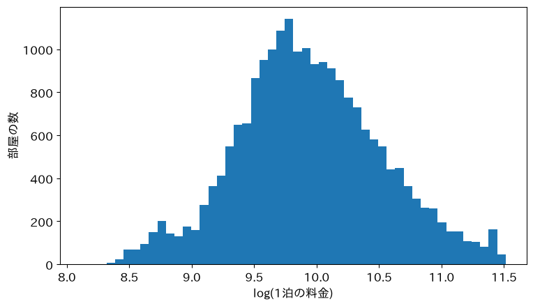

```python
log_price = np.log(tr['料金'])
print(round(tr['料金'].skew(), 2), round(log_price.skew(), 2))
plt.hist(log_price, bins=50)
plt.xlabel('log(1泊の料金)')
plt.ylabel('部屋の数')
plt.show()
```

歪度は、元の料金の1.78から、対数にすると0.13まで小さくなり、ヒストグラムもほぼ左右対称の山になります。

対数にすると、料金の「差」が「比」になります。2万円と4万円の差も、5万円と10万円の差も、どちらも2倍なので、対数では同じ幅です。料金は「何円高い」より「何倍高い」で決まりやすい量なので、対数のほうが式で表しやすくなります。高い部屋の大きな料金に、式が引っぱられにくくもなります。

### 変えてみる：対数の料金を当てる式を作る

当てる値を料金$y$ではなく$\log y$にして式を作り、予測を`np.exp`で円に戻します。

$$\log \hat{y}_i = b_0 + \sum_j b_j x_{ij}, \qquad \hat{y}_i = \exp(\log \hat{y}_i)$$

`np.exp`は、`np.log`の逆で、対数から元の値に戻す関数です。手がかりは7節の`A_tr`（数の列と地区のダミー変数）のままです。

```python
m_log = LinearRegression().fit(A_tr, np.log(tr_f['料金']))
pred_log = np.exp(m_log.predict(A_te))           # 円に戻す
print(mae(te_f['料金'], pred_log), '円')
```

```
7934 円
```

MAEは7,934円です。対数にする前（8,215円）より、さらに300円近く縮みました。これで、数の列の補完・目盛り・文字の列・当てる値の形、と一通り整いました。

## 9. 同じ整え方を何度でも

ここまでで、整え方がそろいました。バスルーム数は文字から戻し、寝室数とベッド数は訓練で作った式で予測して補完し、地区は訓練の列にそろえたダミー変数にします。この整え方は、訓練にも、テストにも、そしてあなたの部屋にも、同じように当てる必要があります。毎回同じ行を書き写すと、どこかでずれます。1つの関数にまとめます。

### お手本：整え方を1つの関数にまとめる

- 役割：補完の方法とダミー変数の列を`base`で決め、表`d`を整えて、手がかりの表を返す
- 入力：決める表`base`、整える表`d`
- 出力：数の列8本と地区のダミー変数48本の表

関数の中で、3節の`fill_bath`と5節の`fill_reg`を呼んでいます。ダミー変数の列（`area_cols`）も`base`から決め、`d`の列をそれにそろえます。小さな関数を組み合わせて、大きな処理を作るのです。式は、8節と同じく対数の料金を当てます。

```python
def prep(base, d):           # 決めるのは base、整えるのは d
    d = fill_bath(d)
    d = fill_reg(base, d, '寝室数')
    d = fill_reg(base, d, 'ベッド数')
    area_cols = pd.get_dummies(base['地区'], drop_first=True).columns
    area = pd.get_dummies(d['地区'], dtype=int)
    area = area.reindex(columns=area_cols, fill_value=0)
    return pd.concat([d[cols], area], axis=1)

model = LinearRegression().fit(prep(tr, tr), np.log(tr['料金']))
err = mae(te['料金'], np.exp(model.predict(prep(tr, te))))
print('訓練で決めた:', err, '円')
```

```
訓練で決めた: 7934 円
```

8節と同じ7,934円です。3節・5節・7節で書いた整え方が、`prep(tr, tr)`と`prep(tr, te)`の2つの呼び出しになりました。

### 変えてみる：全データで決めると

`prep`の最初の引数を、訓練`tr`から全データ`df`に変えるだけです。テストの部屋も含めて、予測の式とダミー変数の列を決めることになります。

```python
model_l = LinearRegression().fit(prep(df, tr), np.log(tr['料金']))
err_l = mae(te['料金'], np.exp(model_l.predict(prep(df, te))))
print('全データで決めた:', err_l, '円')
```

```
全データで決めた: 7934 円
```

全データで決めても7,934円で、差は出ませんでした。2万件以上もあると、テストの5千件を混ぜても、定員から寝室数を当てる式はほとんど変わらず、地区の顔ぶれも同じだからです。

それでも、整え方は訓練だけで決めます。テストの情報が前処理を通して式に漏れることを、第2回で見たリーク（leakage）と同じく避けるためです。データが少ないときや、テストの部屋だけ傾向が違うときには、差が大きく出ます。差が出るかどうかを確かめてから順番を守るのではなく、いつも訓練だけで決める習慣にします。`prep(base, d)`のように「決める表」と「整える表」を分けて受け取る関数にしておくと、この順番を間違えにくくなります。

## 10. 1泊いくら？

整え方を`prep`1つにまとめました。いよいよ、あなたの部屋に値段を付けます。

### お手本：あなたの部屋を値付けする

- 役割：あなたの部屋の条件を1行の表にし、`prep`で整えて、料金の式で値付けする
- 入力：あなたの部屋の表`my_room`
- 出力：1泊の値段（円）

例えば「墨田区（`Sumida Ku`）にある、定員4人、寝室2・ベッド2・バスルーム1」の貸切の部屋です。レビューはまだ0件、最低宿泊数は2泊、この先1年で200日予約を受け付け、ホストの掲載はこの1件だけとします。新しい部屋にも、訓練で決めた同じ整え方を当てます。`prep`の2つ目の引数に、新しい部屋を渡すだけです。地区のダミー変数も、訓練の48本の列にそろいます。`pd.DataFrame({列名: [値], ...})`で、1行の表を作れます。

```python
my_room = pd.DataFrame({'地区': ['Sumida Ku'],
                        '定員': [4], '寝室数': [2],
                        'ベッド数': [2], 'バスルーム数': [1],
                        'バスルームの表記': ['1 bath'],
                        '最低宿泊数': [2], '予約可能日数': [200],
                        'レビュー数': [0], 'ホストの掲載数': [1]})
price = np.exp(model.predict(prep(tr, my_room))[0])
print(round(price), '円')
```

```
21142 円
```

答えは21,142円です。予測は並びで返るので、`[0]`で1つ目を取り出し、`np.exp`で円に戻しています。

### TODO⑤：あなたの番。自分の部屋を値付けする

地区・定員・寝室数などを自分で決めて、1泊の値付けの目安を出してください。寝室数が分からない部屋なら、`np.nan`（欠測値）を入れてもかまいません。`prep`が、訓練で作った式で補完してくれます。

```python
# TODO: my_room の条件を変えた部屋を作り、prep と model で値付けする
# ヒント: room2 = my_room.assign(地区='Minato Ku')
#         のように、assign で列の値を変えた表を作れる。最後に np.exp
...;
```

同じ部屋でも、港区（`Minato Ku`）なら約3万2千円、大田区（`Ota Ku`）なら約1万7千円です。定員2人・寝室1・ベッド1なら約1万6千円、寝室数を`np.nan`にすると、寝室数を定員から予測して約2万円になります。

### 答え

墨田区にあるあなたの部屋（定員4人・寝室2・ベッド2・バスルーム1）は、1泊およそ2万1千円（21,142円）。まだ見ていない部屋でのMAEは、およそ7,900円。相場に入れる部屋を1泊10万円以下の貸切とした場合の値段です。

まだ言えないこと

- MAEだけで測ってよいのか：大きな誤差を重く見る物差しもある
- 件数の少ない地区：檜原村（訓練に3件）や稲城市（1件）のように数件しかない地区のダミー変数は、その数件の料金だけで係数が決まり、当てにならない
- 補完した値の揺れ：回帰補完した値は1本の線に乗るので、真の値より揃いすぎている（発展で扱う）

## 目標に答えられたか

- 今日の目標は「自分の部屋に、1泊いくらの値段を付ければいいか」でした。10節の答えは何円で、どれくらい外れうるでしょうか？
- 1節で、10万円を超える部屋と、貸切以外の部屋を外しました。それぞれ外した理由を、今日の目標から説明できますか？
- 3節で、レビューの点数・バスルーム数・寝室数の欠測を、それぞれどう扱いましたか？ なぜ扱いが違ったのでしょうか？
- 4節で、平均値補完するのはなぜよくないと分かりましたか？MAE・図・相関の3つで説明できますか？
- 7節で、地区に番号を振るのをやめ、ダミー変数にしたのはなぜですか？
- 8節で、料金を対数にすると、何が変わりましたか？
- 9節の`prep`は、なぜ「決める表」と「整える表」の2つを受け取るのでしょうか？

## 今日の要点

- 今日、持ち帰る1文：欠測値は、1つの値で補完しない。欠測した理由を確かめ、ほかの列から予測して補完する。整え方は訓練データだけで決め、関数にして、新しい部屋にも同じように当てる
- 外す行は、目標から理由を説明でき、どこで線を引いたかを書き残せるときに外す
- 欠測値は、理由を先に確かめる。値が存在しない欠測（レビューの点数）は補完しない。別の列から戻せる欠測（バスルーム数）は戻す
- 平均値補完すると、補完値の誤差が大きく、列どうしの関係が弱まる。小さい部屋ほど欠測するときは、平均そのものもずれる
- 答えの分かる欠測を作れば、補完の方法を評価できる
- 標準化と正規化で目盛りをそろえられる。線形回帰の予測は変わらないが、係数を同じ目盛りで比べられる。正規化は極端な値に弱い
- 区分を表す文字の列に番号を振らない。ダミー変数にして、訓練の列にそろえる
- 右に尾の長い料金は、対数にすると式で表しやすく、極端な値にも引っぱられにくい
- Python：`def`で関数を作る。引数が入力、`return`の後ろが戻り値。既定値つきの引数で選択肢を切り替え、小さな関数を組み合わせて大きな処理を作る

## 次回へ

今日は、データを整えて、あなたの部屋に1泊およそ2万1千円の値段を付けました。ただ、MAEだけで式を測ってよいのか、式の係数をどう読めばよいのかには、まだ答えていません。

次回は、場面を住宅の査定に変えます。次回の問いは、「この家は、なぜこの値段なのか」を説明する式を、どの物差しで選び、どう読むか、です。

## 課題（提出）

提出するもの：応用②の答えと、応用③の文章。提出フォームに入力してください。期限はありません。応用①のコードは提出しませんが、②の答えを出すために必要です。

### 応用①（変形）

4節では、ベッド数を欠測させて、平均値補完の場合と、回帰補完した場合を評価しました。同じことを、寝室数でやってください。寝室数が分かっている訓練の部屋`full_bed`から、`make_missing`で`rate=0.2`の欠測を作り、平均値補完のときと`fill_reg`で回帰補完したときの、欠測させた部屋でのMAEを表示してください。

```python
# ここにコードを書く
...;
```

**詰まったら**

まず`full_bed = tr[tr['寝室数'].notna()]`で、寝室数が分かっている部屋を取り出します。 4節の「平均値補完して、評価する」のセルを写し、`full`を`full_bed`に、`'ベッド数'`を`'寝室数'`に変えます。真の値も`full_bed['寝室数']`にします。回帰補完するのは、5節の`fill_reg(practice, practice, '寝室数')`を使うと1行で書けます。

### 応用②（判断）

応用①で、寝室数を平均値補完のとき、欠測させた部屋でのMAEは何室ですか。小数第2位まで答えてください（例: 0.12）。

```python
# ここにコードを書く
...;
```

**詰まったら**

`round(値, 2)`で小数第2位に丸めます。回帰補完したときのMAEとも比べておきましょう。

### 応用③（解釈）

応用①の結果と4節の図をもとに、「欠測した寝室数を、平均値補完してはいけない理由」と「代わりにどう補完するか」を、民泊の新しいホストに向けて3行程度で説明してください。

（ここに3行程度で書く）

## 発展（任意）

### 予測値にランダムな誤差を足して補完する（確率的回帰補完）：多重代入の考え方

4節で、定員から回帰補完すると、相関が真の0.848より強めに出ました（`rate=0.2`で0.863）。予測値は、どれも1本の線の上にぴったり乗るからです。真のベッド数は、同じ定員でも部屋ごとに散らばっています。回帰補完した部屋だけ、散らばりが消えているのです。

そこで、予測値に、真の値と予測の誤差と同じくらいのランダムな誤差を足して補完します。

$$\tilde{x}_i = \hat{x}_i + \varepsilon_i, \qquad \varepsilon_i \sim N(0,\, s^2)$$

$\hat{x}_i$は予測値、$\varepsilon_i$は平均0・標準偏差$s$の正規分布に従う乱数です。この補完を、確率的回帰補完（stochastic regression imputation）と呼びます。$s$は、値の分かる部屋での予測の誤差$x_k - \hat{x}_k$の標準偏差にします。

- 役割：予測の誤差の散らばりを測り、その大きさの乱数を予測値に足して補完する
- 入力：4節の`full`と`make_missing`・`fill_reg`
- 出力：ランダムな誤差を足したときの相関と標準偏差

`rng.normal(0, s, 個数)`は、平均0・標準偏差`s`の正規分布に従う乱数を、指定した個数だけ出します。

```python
truth = full['ベッド数']
practice = make_missing(full, 'ベッド数', 0.2)
miss = practice['ベッド数'].isna()
ok = practice[practice['ベッド数'].notna()]
m = LinearRegression().fit(ok[['定員']], ok['ベッド数'])
# 予測の誤差の散らばり（標準偏差）
s = (ok['ベッド数'] - m.predict(ok[['定員']])).std()
print('予測の誤差の標準偏差:', round(s, 2))

by_reg = fill_reg(practice, practice, 'ベッド数')['ベッド数']
rng = np.random.default_rng(1)
by_noise = by_reg.copy()
by_noise[miss] = by_reg[miss] + rng.normal(0, s, miss.sum())
for name, val in [('真の値', truth), ('回帰補完', by_reg),
                  ('確率的回帰補完', by_noise)]:
    print(name, ' 相関', round(full['定員'].corr(val), 3),
          ' 標準偏差', round(val.std(), 2))
print('0より小さい値:', (by_noise[miss] < 0).sum(), '件')
```

```
予測の誤差の標準偏差: 1.21
真の値  相関 0.848  標準偏差 2.16
回帰補完  相関 0.863  標準偏差 2.11
確率的回帰補完  相関 0.833  標準偏差 2.19
0より小さい値: 342 件
```

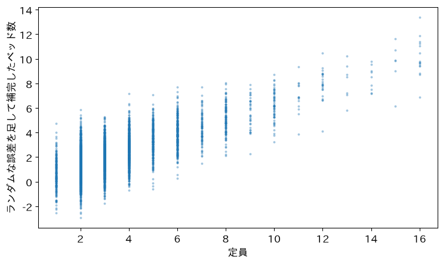

```python
plt.scatter(full['定員'][miss], by_noise[miss], s=4, alpha=0.3)
plt.xlabel('定員')
plt.ylabel('ランダムな誤差を足して補完したベッド数')
plt.show()
```

読み方 回帰補完だけのときは、相関0.863・標準偏差2.11で、真の値（0.848・2.16）より揃いすぎていました。ランダムな誤差を足すと、今度は相関0.833・標準偏差2.19と、反対側にずれます。図の点も1本の線ではなくなりますが、0より小さいベッド数が342件も出てしまいます。

散らばりすぎる理由は、どの部屋にも同じ大きさのランダムな誤差を足したことです。真のベッド数は、定員の小さい部屋ではあまり散らばらず、大きい部屋ではよく散らばります。それなのに、小さい部屋にも大きい部屋と同じ$s=1.21$のランダムな誤差を足しました。本格的な方法では、ランダムな誤差の大きさも部屋に合わせてデータから決めます。

それでも、ランダムな誤差を足すという考え方には意味があります。足したランダムな誤差は乱数なので、種を変えれば補完した値も変わります。そこで、種を変えて補完したデータを何通りも作り、それぞれで同じ分析をして、結果をまとめます。補完した値の不確かさを、結果の幅として残せるのです。この方法を多重代入（multiple imputation）と呼びます。

```python
for seed in range(5):
    rng = np.random.default_rng(seed)
    by_noise = by_reg.copy()
    by_noise[miss] = by_reg[miss] + rng.normal(0, s, miss.sum())
    print(seed, by_noise[miss].head(3).round(1).values,
          ' 相関', round(full['定員'].corr(by_noise), 3))
```

```
0 [3.4 1.8 3.4]  相関 0.833
1 [3.6 3.  3. ]  相関 0.833
2 [3.5 1.3 2.1]  相関 0.833
3 [ 5.7 -1.1  3.1]  相関 0.833
4 [2.4 1.8 4.6]  相関 0.833
```

欠測させた部屋の最初の3件に入る値は、種ごとに違います。補完した値がどれくらい不確かかが、種による違いとして見えるのです。試すなら、`rate`を0.4に上げて、回帰補完だけのとき・ランダムな誤差を足したときの相関と標準偏差が、真の値からどちらにどれだけずれるかを比べてみましょう。

### 外す線で、値段は変わるか

本編で出したあなたの部屋の値段は、1節で「1泊10万円以下」に線を引いた結果です。線を変えたら、値段はどれくらい変わるのでしょうか。

#### お手本：外す線を引数にした関数

- 役割：`cut`円以下の貸切の部屋で、絞る・分ける・整えて式を作る・値付けして評価する、を通して行う
- 入力：外す線`cut`（既定値は10万円）
- 出力：なし（値段とMAEを表示する）

長く見えますが、新しい書き方はありません。今日これまでに書いたセルを、4つのかたまりで並べただけです。

1. 絞る（3行）：1節と同じ。10万円の代わりに`cut`を使う
2. 分ける（1行）：1節と同じ`train_test_split`
3. 整えて式を作る（1行）：9節の`prep`と同じ。対数の料金を当てる
4. 値付けして評価する（3行）：10節の値付けと、2節の`mae`

`cut=100000`のように既定値を書いておくと、`price_for()`とかっこだけで呼べば10万円で、`price_for(50000)`と書けば5万円で動きます。

```python
def price_for(cut=100000):
    d = raw[raw['料金'] <= cut]
    d = d[d['部屋のタイプ'] == 'Entire home/apt']
    d = d[d['最低宿泊数'].notna()]
    tr2, te2 = train_test_split(d, test_size=0.2, random_state=42)
    m = LinearRegression().fit(prep(tr2, tr2), np.log(tr2['料金']))
    p = np.exp(m.predict(prep(tr2, my_room))[0])
    err = mae(te2['料金'], np.exp(m.predict(prep(tr2, te2))))
    print(cut, '円まで:', round(p), '円  MAE', err, '円')

price_for()
```

```
100000 円まで: 21142 円  MAE 7934 円
```

既定値の10万円では、本編の10節と同じ21,142円・7,934円です。

#### 変えてみる：線を動かす

`for`文で、外す線を3万円から1千万円（実質、外さない）まで変えて呼びます。

```python
for cut in [30000, 50000, 100000, 300000, 10000000]:
    price_for(cut)
```

```
30000 円まで: 18188 円  MAE 4005 円
50000 円まで: 20102 円  MAE 5780 円
100000 円まで: 21142 円  MAE 7934 円
300000 円まで: 20950 円  MAE 9830 円
10000000 円まで: 21876 円  MAE 15083 円
```

5万円・10万円・30万円で切っても、外さなくても、あなたの部屋の値段は20,102円〜21,876円で、ほとんど変わりません。料金を対数にしたので、1泊数百万円の部屋があっても、式が引っぱられにくいのです。3万円で切ったときだけ18,188円と下がるのは、ふつうの貸切（中央値は約2万円）まで外してしまうからです。

#### 問い：MAEが、どんどん小さくなる

一方で、MAEは、外さないときの15,083円から、3万円で切ると4,005円まで縮みます。線を厳しくするほど、式は良くなったのでしょうか。下に書いてください。

（ここに予想を書く）

良くなったとは言えません。線を変えると、テストの部屋そのものが変わるからです。3万円で切ると、当てにくい高い部屋がテストからも消え、3万円以下の部屋だけで評価しています。評価する部屋が違うMAEは、比べられません。第2回で見た「採点が甘い」と同じ落とし穴です。

線は、MAEが小さくなるように選ぶのではなく、目標から選びます。あなたの部屋は定員4人のふつうの部屋で、1泊数十万円の一棟貸しと競うわけではありません。だから10万円の線を使い、その線を書き残します。